# Final Project

Mei Lin Verghese Law Kung Sam(s194685), Thelma Urena(s242552), Alejandra Caballero(s231912),Marco Bonafede(s243247), Carlos Sainz(s253695)

## Introduction

Our project is based on dataset GEOquery **[GSE54514]**

And **this** paper

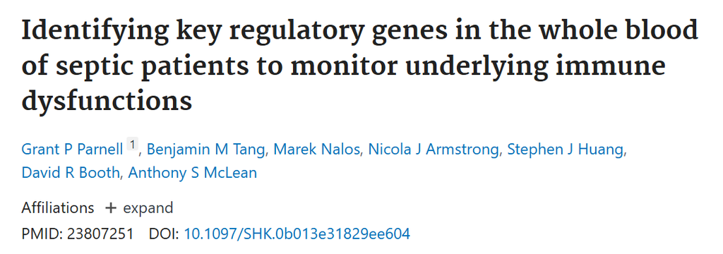

## Materials and Methods

The raw data:

| sample | characteristics |
| --- | --- |
| GSM1317896 | tissue: whole blood |
| GSM1317896 | disease status: healthy |
| GSM1317896 | group_day: HC_D1 |
| GSM1317896 | group_id: HC_1 |
| GSM1317896 | gender: F |
| GSM1317896 | age (years): 42 |
| GSM1317896 | severity (apacheii): NA |
| GSM1317896 | neutrophil proportion: 0.461538462 |
| GSM1317896 | site of infection: NA |
| GSM1317897 | tissue: whole blood |

[output cut: 1457 more lines]

```
dimension = 1467 x 2
```

```
Number of samples = 163
```

But a tidy data set should follow these rules:

- Every column contains exactly one variable.
- Every row represents exactly one experimental unit (sample).
- Every cell contains exactly one measurement.

## Materials and Methods

Merge `gene_names` and `expression_data`

```r
merged_data <- expression_data |>
  left_join(annotation_data, by = "ILMN_ID")
```

Filter so it is only genes of interest

```r
merged_data_clean <- merged_data |>
  dplyr::filter(Gene_ID %in% gene_list)
```

If gene has more than 1 `ILMN_ID`, get average of gene expression

```r
clean_data <- merged_data_clean |>
  group_by(Gene_ID) |>
  summarise(across(starts_with("GSM"), mean, na.rm = TRUE)) |>
  ungroup()
```

Pivot and merge by `sample`

```r
second_clean <- clean_data |>
  pivot_longer(
    cols = starts_with("GSM"),
    names_to = "sample",
    values_to = "expression"
  )

merged_final <- second_clean |>
  left_join(meta_clean, by = "sample")
```

| Gene_ID | sample | expression | disease status | day | group_id | gender | age (years) | severity (apacheii) | neutrophil proportion | site of infection |
| --- | --- | --- | --- | --- | --- | --- | --- | --- | --- | --- |
| B2M | GSM1317896 | 14.060449125 | healthy | D1 | HC_1 | F | 42 | NA | 0.461538462 | NA |
| B2M | GSM1317897 | 13.605147365 | healthy | D1 | HC_2 | F | 40 | NA | 0.53030303 | NA |
| B2M | GSM1317898 | 13.771077635 | healthy | D1 | HC_3 | M | 66 | NA | 0.630136986 | NA |
| B2M | GSM1317899 | 13.716136455 | healthy | D1 | HC_4 | M | 24 | NA | 0.615384615 | NA |
| B2M | GSM1317900 | 13.52723074 | healthy | D1 | HC_5 | F | 70 | NA | 0.583333333 | NA |
| B2M | GSM1317901 | 13.54407072 | healthy | D1 | HC_6 | F | 45 | NA | 0.590163934 | NA |
| B2M | GSM1317902 | 14.002583025 | healthy | D1 | HC_7 | F | 60 | NA | 0.634920635 | NA |
| B2M | GSM1317903 | 14.021234035 | healthy | D1 | HC_8 | F | 36 | NA | 0.547945205 | NA |
| B2M | GSM1317904 | 14.33772707 | healthy | D1 | HC_9 | M | 47 | NA | 0.534482759 | NA |
| B2M | GSM1317905 | 13.6879797 | healthy | D1 | HC_10 | F | 45 | NA | 0.650793651 | NA |

[output cut: 2435 more lines]

```
dimension = 2445 x 11
```

## Materials and Methods

Separate `characteristics` into key/value pairs

```r
meta_separated <- meta_untidy |>
  separate(characteristics, into = c("key", "value"), sep = ": ")
```

Convert long format to wide format

```r
meta_wide <- meta_separated |>
  pivot_wider(names_from = key, values_from = value)
```

Replace string `"NA"` with actual `NA`

```r
meta_wide <- meta_wide |>
  mutate_all(~ ifelse(. == "NA", NA, .))
```

Split `group_day` into two variables

```r
meta_clean <- meta_wide |>
  separate(group_day, into = c("group_temp", "day"), sep = "_", remove = TRUE) |>
  select(-group_temp)
```

| sample | disease status | day | group_id | gender | age (years) | severity (apacheii) | neutrophil proportion | site of infection |
| --- | --- | --- | --- | --- | --- | --- | --- | --- |
| GSM1317896 | healthy | D1 | HC_1 | F | 42 | NA | 0.461538462 | NA |
| GSM1317897 | healthy | D1 | HC_2 | F | 40 | NA | 0.53030303 | NA |
| GSM1317898 | healthy | D1 | HC_3 | M | 66 | NA | 0.630136986 | NA |
| GSM1317899 | healthy | D1 | HC_4 | M | 24 | NA | 0.615384615 | NA |
| GSM1317900 | healthy | D1 | HC_5 | F | 70 | NA | 0.583333333 | NA |
| GSM1317901 | healthy | D1 | HC_6 | F | 45 | NA | 0.590163934 | NA |
| GSM1317902 | healthy | D1 | HC_7 | F | 60 | NA | 0.634920635 | NA |
| GSM1317903 | healthy | D1 | HC_8 | F | 36 | NA | 0.547945205 | NA |
| GSM1317904 | healthy | D1 | HC_9 | M | 47 | NA | 0.534482759 | NA |
| GSM1317905 | healthy | D1 | HC_10 | F | 45 | NA | 0.650793651 | NA |

[output cut: 153 more lines]

## Materials and Methods

Which `samples` are in the `control` group

```r
pheno_data_control <- pheno_data |>
  mutate(control = str_detect(title, '(Control)'))  |>
  mutate(control = factor(control, levels = c(TRUE, FALSE)))  |>
  group_by(control)
```

Merge `phenotype data`, `expression data` and `platform data`

```r
merged_pheno_control <- merged_unfiltered |>
  left_join(y = pheno_data_control,
            by = join_by(sample == geo_accession))
```

| Gene_ID | sample | expression | control |
| --- | --- | --- | --- |
| SMYD2 | GSM1318039 | 7.11357069 | FALSE |
| TNFAIP8 | GSM1317980 | 7.286878347 | FALSE |
| ARHGAP11B | GSM1318016 | 7.238760948 | FALSE |
| LOC652771 | GSM1317937 | 7.065806866 | FALSE |
| C16ORF63 | GSM1318008 | 8.084902763 | FALSE |
| HS.543909 | GSM1317999 | 7.109963894 | FALSE |
| LSG1 | GSM1317996 | 7.121051311 | FALSE |
| HS.542687 | GSM1317929 | 7.111014366 | FALSE |
| HS.562917 | GSM1317996 | 7.233275414 | FALSE |
| HS.541596 | GSM1317976 | 7.142333508 | FALSE |

[output cut: 990 more lines]

## Results and Discussion

| Gene_ID | difference_mean_gene_expression | control | mean_gene_expression |
| --- | --- | --- | --- |
| A1BG | -0.00620630585301817 | True | 7.20106624233333 |
| A1BG | -0.00620630585301817 | False | 7.19485993648031 |
| A1CF | 0.00436435960367465 | True | 7.11462061933333 |
| A1CF | 0.00436435960367465 | False | 7.11898497893701 |
| A26A1 | 0.01216096307021 | True | 7.20460926158333 |
| A26A1 | 0.01216096307021 | False | 7.21677022465354 |
| A26C1B | 0.0406002207591864 | True | 7.11704138908333 |
| A26C1B | 0.0406002207591864 | False | 7.15764160984252 |
| A26C3 | 0.00990573800918603 | True | 7.28401852983333 |
| A26C3 | 0.00990573800918603 | False | 7.29392426784252 |

[output cut: 39644 more lines]

## Results and Discussion

Boxplots for expression per gene in survivors vs non-survivors

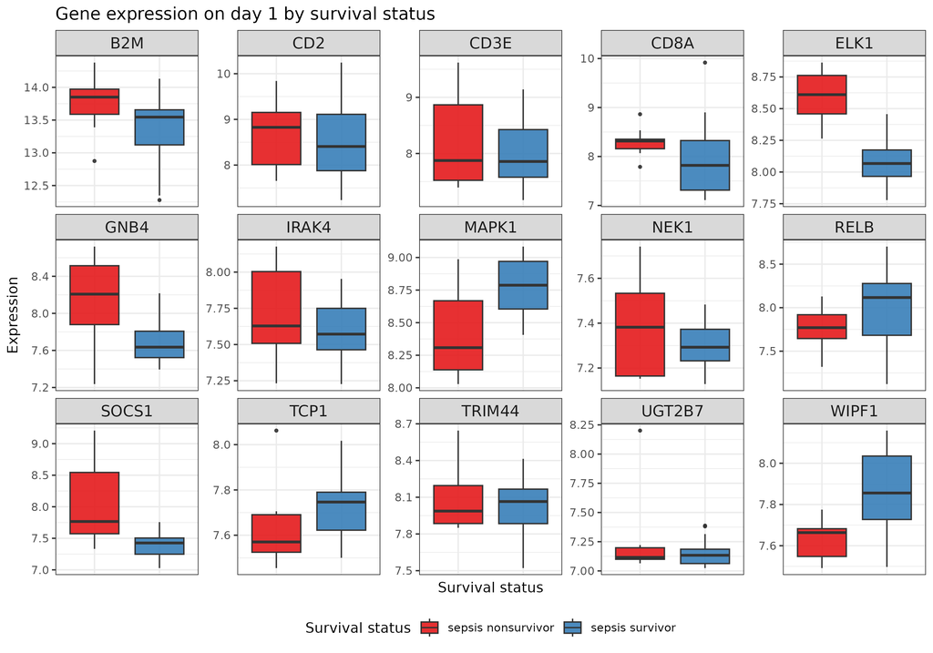

## Results and Discussion

Difference in day 1 gene expression in survivors vs non-survivors

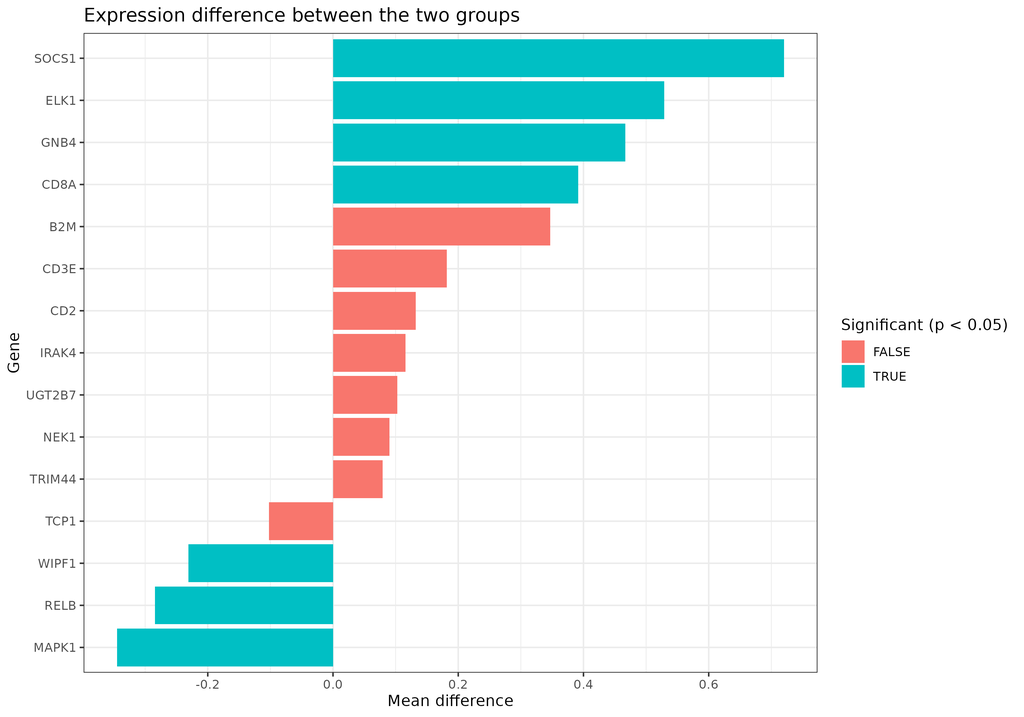

## Results and Discussion

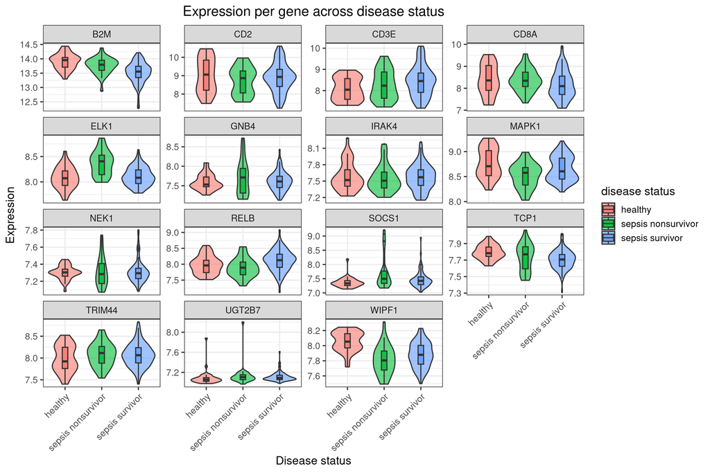

## Results and Discussion

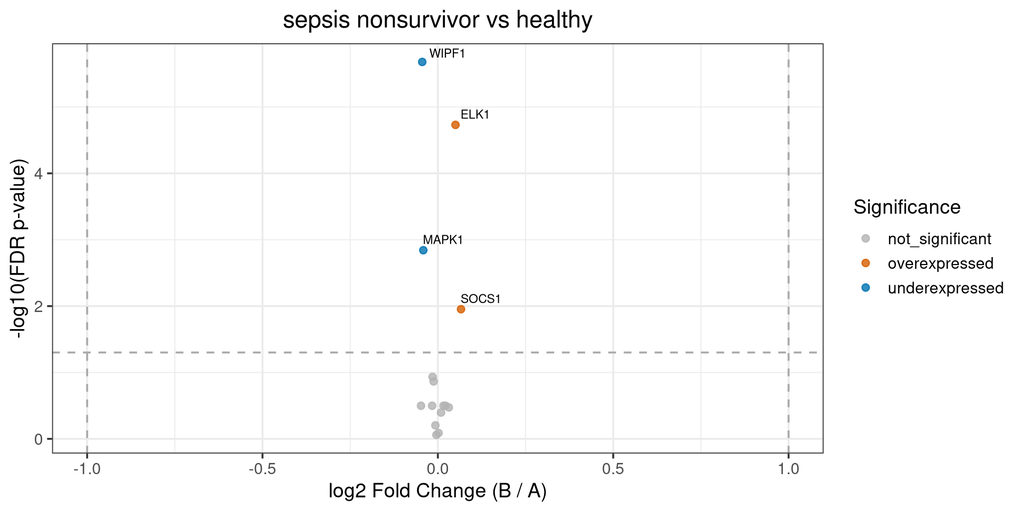